# 極度に貧しい！？

2023-12-11

> UNICEF [[Link](https://www.unicef.or.jp/kodomo/sdgs/17goals/1-poverty/)]
> 1. 世界では、六人に一人（3億5600万人）の子どもたちが「極度にまずしい」暮らしをしています。

どのようなデータから、このようなことがわかるのでしょうか。まずは、極度の貧困とは、どのように定義しているのでしょうか。

#### 0.0.0.1 Fact Sheet: An Adjustment to Global Poverty Lines [[Link](https://www.worldbank.org/en/news/factsheet/2022/05/02/fact-sheet-an-adjustment-to-global-poverty-lines)]

The World Bank updated the global poverty lines in September 2022. The decision, announced in May, follows the release in 2020 of new purchasing power parities (PPPs)—the main data used to convert different currencies into a common, comparable unit and account for price differences across countries. The new extreme poverty line of $2.15 per person per day, which replaces the $1.90 poverty line, is based on 2017 PPPs. Here you find more information about this change and what it means for measuring global poverty.

世界銀行は2022年9月に世界の貧困ラインを更新した。5月に発表されたこの決定は、2020年に新購買力平価（PPP）が発表されたことを受けてのものである。新購買力平価（PPP）とは、さまざまな通貨を共通の比較可能な単位に変換し、貧困の範囲を説明するために使用される主要なデータである。国ごとの価格差。1.90ドルの貧困線に代わる、1人当たり1日当たり2.15ドルという新たな極度の貧困線は、2017年のPPPに基づいている。ここでは、この変化とそれが世界の貧困の測定に何を意味するかに関する詳細情報をご覧いただけます。

そこで、この購買力平価（PPP: purchasing power parities）をまずは、調べてみましょう。国や、地域ごとの、GDP, PPP と言われるものと、それを、人口で割った、一人当たりの、GDP PPP と言われるものです。2017年を基準として、インフレ率を調整してあります。GDP は国内総生産（Gross Domestic Prodoct）の略で、何種類か計算方法がありますが、基本的な経済指標で、ドル換算されています。

- GDP, PPP (constant 2017 international $): NY.GDP.MKTP.PP.KD
- GDP per capita, PPP (constant 2017 international $): NY.GDP.PCAP.PP.KD

GDP, PPP (constant 2017 international $) とか、GDP per capita, PPP (constant 2017 international $) を、指標名（Indicator Name）といい、NY.GDP.MKTP.PP.KD とか、NY.GDP.PCAP.PP.KD を、指標コード（Indicator Code）と言います。後者を、WDI（世界開発指標、World Development Indicator）と呼ぶこともあります。

### 0.0.1 準備

Step 1. （R に機能を付け加える）パッケージのインストール（最初だけ）

```r
install.packages("tidyverse")
install.packages("WDI")
```

Step 2. パッケージを使えるように読み込みます。

```r
library(tidyverse)
library(WDI)
```

Step 3. データを保存するための data という名前のディレクトリ（フォルダー）を作成します。（最初だけ）

```r
dir.create("data")
```

Step 4. エラーが生じた時に、調べやすいので、‘システム言語（System Language）’ を英語にしておきます。（最初だけ）

```r
Sys.setenv(LANG = "en")
```

Step 5. データを読み込みます。WDI パッケージをつかうと、簡単に、データを読み込むことができます。わかりやすい名前（gdp、gdppcap）をつけ、人口（pop）も読み込んでおきます。extra = TRUE としておくと、使い情報を一緒に読み込むことができます。（すでに、data に、gdppcap.csv というのがあるときは、Step 5, Step 6 はスキップして、Step 7 だけを実行します。）

```r
df_gdppcap <- WDI(indicator = c(gdp = "NY.GDP.MKTP.PP.KD", pop = "SP.POP.TOTL", gdppcap = "NY.GDP.PCAP.PP.KD"), extra = TRUE)
```

Step 6. 何度も読み込むのは、時間もかかりますから、最初に作った、data という、ディレクトリー（フォルダ）に保存しておきます。（すでに、data に、gdppcap.csv というのがあるときは、Step 5, Step 6 はスキップして、Step 7 だけを実行します。）

```r
write_csv(df_gdppcap, "data/gdppcap.csv")
```

Step 7. 保存したものを読み込みます。（すでに、data に、gdppcap.csv というのがあるときは、Step 5, Step 6 はスキップして、Step 7 だけを実行します。）

```r
df_gdppcap <- read_csv("data/gdppcap.csv")
```

Step 8. データの最初の６行（rows）をみてみます。

```r
head(df_gdppcap)
```

| country | iso2c | iso3c | year | status | lastupdated | gdp | pop | gdppcap | region | capital | longitude | latitude | income | lending |
| --- | --- | --- | --- | --- | --- | --- | --- | --- | --- | --- | --- | --- | --- | --- |
| Afghanistan | AF | AFG | 2014 | NA | 2023-10-26 | 70158264545 | 32716210 | 2144.450 | South Asia | Kabul | 69.1761 | 34.5228 | Low income | IDA |
| Afghanistan | AF | AFG | 1971 | NA | 2023-10-26 | NA | 11015857 | NA | South Asia | Kabul | 69.1761 | 34.5228 | Low income | IDA |
| Afghanistan | AF | AFG | 2006 | NA | 2023-10-26 | 34780330056 | 25442944 | 1366.993 | South Asia | Kabul | 69.1761 | 34.5228 | Low income | IDA |
| Afghanistan | AF | AFG | 2013 | NA | 2023-10-26 | 68297470349 | 31541209 | 2165.341 | South Asia | Kabul | 69.1761 | 34.5228 | Low income | IDA |
| Afghanistan | AF | AFG | 1995 | NA | 2023-10-26 | NA | 16418912 | NA | South Asia | Kabul | 69.1761 | 34.5228 | Low income | IDA |
| Afghanistan | AF | AFG | 2005 | NA | 2023-10-26 | 33011757108 | 24411191 | 1352.321 | South Asia | Kabul | 69.1761 | 34.5228 | Low income | IDA |

Step 9. データの列（columns、変数 variables）はどのようなものがあるかを表示します。

```r
str(df_gdppcap)
```

```
spc_tbl_ [16,758 × 15] (S3: spec_tbl_df/tbl_df/tbl/data.frame)
 $ country    : chr [1:16758] "Afghanistan" "Afghanistan" "Afghanistan" "Afghanistan" ...
 $ iso2c      : chr [1:16758] "AF" "AF" "AF" "AF" ...
 $ iso3c      : chr [1:16758] "AFG" "AFG" "AFG" "AFG" ...
 $ year       : num [1:16758] 2014 1971 2006 2013 1995 ...
 $ status     : logi [1:16758] NA NA NA NA NA NA ...
 $ lastupdated: Date[1:16758], format: "2023-10-26" "2023-10-26" ...
 $ gdp        : num [1:16758] 7.02e+10 NA 3.48e+10 6.83e+10 NA ...
 $ pop        : num [1:16758] 32716210 11015857 25442944 31541209 16418912 ...
 $ gdppcap    : num [1:16758] 2144 NA 1367 2165 NA ...
 $ region     : chr [1:16758] "South Asia" "South Asia" "South Asia" "South Asia" ...
 $ capital    : chr [1:16758] "Kabul" "Kabul" "Kabul" "Kabul" ...
 $ longitude  : num [1:16758] 69.2 69.2 69.2 69.2 69.2 ...
 $ latitude   : num [1:16758] 34.5 34.5 34.5 34.5 34.5 ...
 $ income     : chr [1:16758] "Low income" "Low income" "Low income" "Low income" ...
 $ lending    : chr [1:16758] "IDA" "IDA" "IDA" "IDA" ...
 - attr(*, "spec")=
  .. cols(
  ..   country = col_character(),
  ..   iso2c = col_character(),
  ..   iso3c = col_character(),
  ..   year = col_double(),
  ..   status = col_logical(),
  ..   lastupdated = col_date(format = ""),
  ..   gdp = col_double(),
  ..   pop = col_double(),
  ..   gdppcap = col_double(),
  ..   region = col_character(),
  ..   capital = col_character(),
  ..   longitude = col_double(),
  ..   latitude = col_double(),
  ..   income = col_character(),
  ..   lending = col_character()
  .. )
 - attr(*, "problems")=<externalptr>
```

Step 10. （ちょっと高度ですが）region, income, lending には、どのようなものがあるか、みてみます。

```r
df_gdppcap |> select(region, income, lending) |> lapply(unique)
```

```
$region
[1] "South Asia"                 "Aggregates"
[3] "Europe & Central Asia"      "Middle East & North Africa"
[5] "East Asia & Pacific"        "Sub-Saharan Africa"
[7] "Latin America & Caribbean"  "North America"
[9] NA

$income
[1] "Low income"          "Aggregates"          "Upper middle income"
[4] "Lower middle income" "High income"         NA
[7] "Not classified"

$lending
[1] "IDA"            "Aggregates"     "IBRD"           "Not classified"
[5] "Blend"          NA
```

Step 11. 世界の GDP の推移（経年変化）を見てみます。

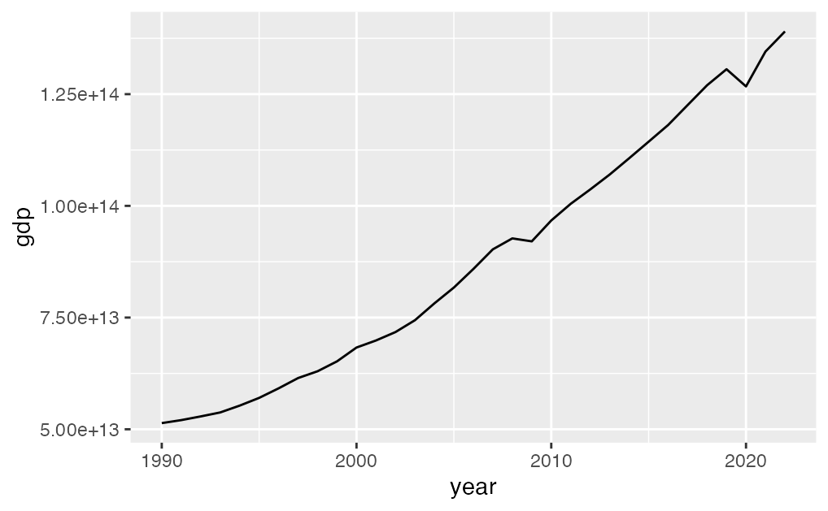

```r
COUNTRY <- "World"
df_gdppcap |> filter(country == COUNTRY) |> drop_na(gdppcap) |>
  ggplot(aes(year, gdp)) + geom_line()
```

Step 12. 世界の GDP per Capita の推移（経年変化）を見てみます。

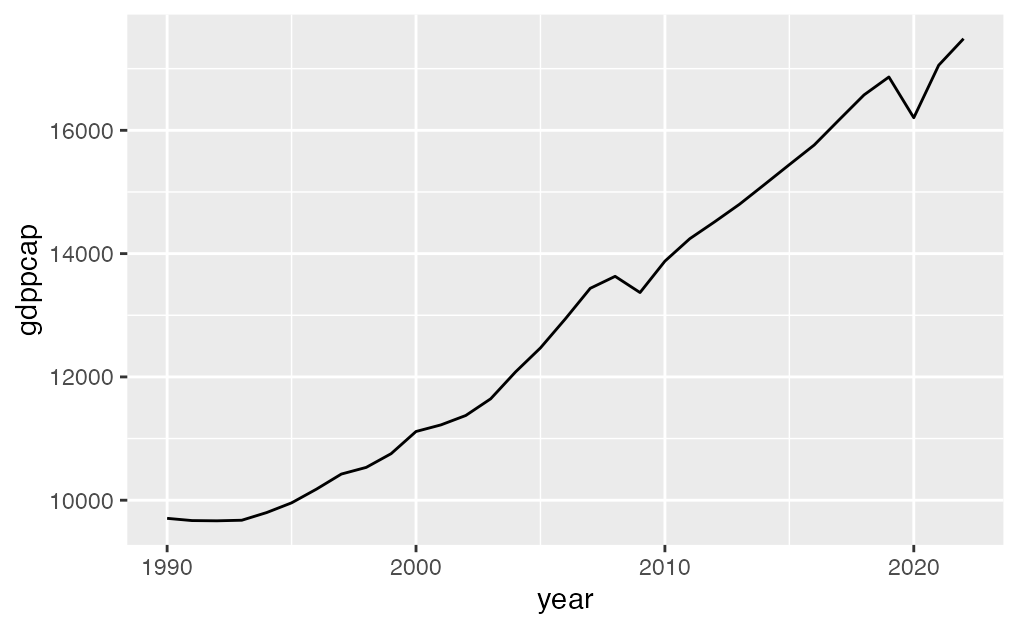

```r
COUNTRY <- "World"
df_gdppcap |> filter(country == COUNTRY) |> drop_na(gdppcap) |>
  ggplot(aes(year, gdppcap)) + geom_line()
```

Step 13. 人口の推移（経年変化）もみてみましょう。

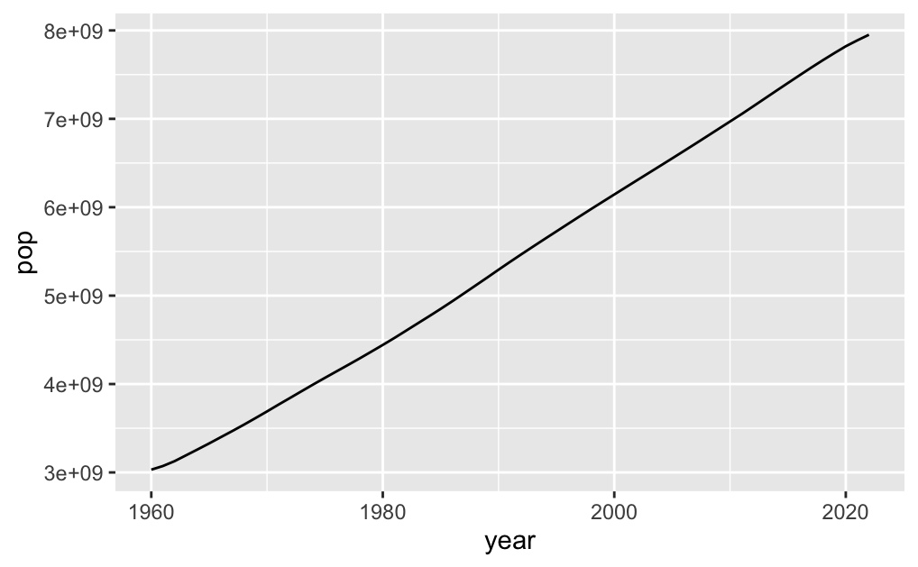

```r
COUNTRY <- "World"
df_gdppcap |> filter(country == COUNTRY) |>
  ggplot(aes(year, pop)) + geom_line()
```

Step 14. 2022年の、GDP の多い国から順に並べてみましょう。

`arrange(desc(gdp))` とすると、大きい順`,` `arrange(gdp)` とすると小さい順に並びます。

```r
df_gdppcap |> filter(year == 2022, region != "Aggregates") |>
  drop_na(gdp) |> arrange(desc(gdp))
```

| country | iso2c | iso3c | year | status | lastupdated | gdp | pop | gdppcap | region | capital | longitude | latitude | income | lending |
| --- | --- | --- | --- | --- | --- | --- | --- | --- | --- | --- | --- | --- | --- | --- |
| China | CN | CHN | 2022 | NA | 2023-10-26 | 2.568461e+13 | 1412175000 | 18187.9787 | East Asia & Pacific | Beijing | 116.286000 | 40.049500 | Upper middle income | IBRD |
| United States | US | USA | 2022 | NA | 2023-10-26 | 2.156470e+13 | 333287557 | 64702.9783 | North America | Washington D.C. | -77.032000 | 38.889500 | High income | Not classified |
| India | IN | IND | 2022 | NA | 2023-10-26 | 1.005674e+13 | 1417173173 | 7096.3389 | South Asia | New Delhi | 77.225000 | 28.635300 | Lower middle income | IBRD |
| Japan | JP | JPN | 2022 | NA | 2023-10-26 | 5.210350e+12 | 125124989 | 41641.1650 | East Asia & Pacific | Tokyo | 139.770000 | 35.670000 | High income | Not classified |
| Germany | DE | DEU | 2022 | NA | 2023-10-26 | 4.503322e+12 | 84079811 | 53560.0911 | Europe & Central Asia | Berlin | 13.411500 | 52.523500 | High income | Not classified |
| Russian Federation | RU | RUS | 2022 | NA | 2023-10-26 | 4.027358e+12 | 143555736 | 27584.1719 | Europe & Central Asia | Moscow | 37.617600 | 55.755800 | Upper middle income | IBRD |
| Indonesia | ID | IDN | 2022 | NA | 2023-10-26 | 3.418905e+12 | 275501339 | 12409.7589 | East Asia & Pacific | Jakarta | 106.830000 | -6.197520 | Lower middle income | IBRD |
| Brazil | BR | BRA | 2022 | NA | 2023-10-26 | 3.249827e+12 | 215313498 | 15093.4651 | Latin America & Caribbean | Brasilia | -47.929200 | -15.780100 | Upper middle income | IBRD |
| United Kingdom | GB | GBR | 2022 | NA | 2023-10-26 | 3.136344e+12 | 66971411 | 46831.0854 | Europe & Central Asia | London | -0.126236 | 51.500200 | High income | Not classified |
| France | FR | FRA | 2022 | NA | 2023-10-26 | 3.126376e+12 | 67935660 | 46019.6654 | Europe & Central Asia | Paris | 2.350970 | 48.856600 | High income | Not classified |

[output cut: 172 more lines]

Step 15. 2022年の、GDP per Capita の多い国から順に並べてみましょう。

```r
df_gdppcap |> filter(year == 2022, region != "Aggregates") |>
  drop_na(gdppcap) |> arrange(desc(gdppcap))
```

[output not shown]

Step 16. 2022年の、Population（人口） の多い国から順に並べてみましょう。

```r
df_gdppcap |> filter(year == 2022, region != "Aggregates") |>
  drop_na(pop) |> arrange(desc(pop))
```

| country | iso2c | iso3c | year | status | lastupdated | gdp | pop | gdppcap | region | capital | longitude | latitude | income | lending |
| --- | --- | --- | --- | --- | --- | --- | --- | --- | --- | --- | --- | --- | --- | --- |
| India | IN | IND | 2022 | NA | 2023-10-26 | 1.005674e+13 | 1417173173 | 7096.3389 | South Asia | New Delhi | 77.225000 | 28.635300 | Lower middle income | IBRD |
| China | CN | CHN | 2022 | NA | 2023-10-26 | 2.568461e+13 | 1412175000 | 18187.9787 | East Asia & Pacific | Beijing | 116.286000 | 40.049500 | Upper middle income | IBRD |
| United States | US | USA | 2022 | NA | 2023-10-26 | 2.156470e+13 | 333287557 | 64702.9783 | North America | Washington D.C. | -77.032000 | 38.889500 | High income | Not classified |
| Indonesia | ID | IDN | 2022 | NA | 2023-10-26 | 3.418905e+12 | 275501339 | 12409.7589 | East Asia & Pacific | Jakarta | 106.830000 | -6.197520 | Lower middle income | IBRD |
| Pakistan | PK | PAK | 2022 | NA | 2023-10-26 | 1.285651e+12 | 235824862 | 5451.7182 | South Asia | Islamabad | 72.800000 | 30.516700 | Lower middle income | Blend |
| Nigeria | NG | NGA | 2022 | NA | 2023-10-26 | 1.084655e+12 | 218541212 | 4963.1603 | Sub-Saharan Africa | Abuja | 7.489060 | 9.058040 | Lower middle income | Blend |
| Brazil | BR | BRA | 2022 | NA | 2023-10-26 | 3.249827e+12 | 215313498 | 15093.4651 | Latin America & Caribbean | Brasilia | -47.929200 | -15.780100 | Upper middle income | IBRD |
| Bangladesh | BD | BGD | 2022 | NA | 2023-10-26 | 1.072141e+12 | 171186372 | 6263.0046 | South Asia | Dhaka | 90.411300 | 23.705500 | Lower middle income | IDA |
| Russian Federation | RU | RUS | 2022 | NA | 2023-10-26 | 4.027358e+12 | 143555736 | 27584.1719 | Europe & Central Asia | Moscow | 37.617600 | 55.755800 | Upper middle income | IBRD |
| Mexico | MX | MEX | 2022 | NA | 2023-10-26 | 2.492365e+12 | 127504125 | 19547.3307 | Latin America & Caribbean | Mexico City | -99.127600 | 19.427000 | Upper middle income | IBRD |

[output cut: 205 more lines]

Step 17. 2022年の、GDP と Population（人口） の関係性を、散布図（Scatter Plot）で見てみましょう。

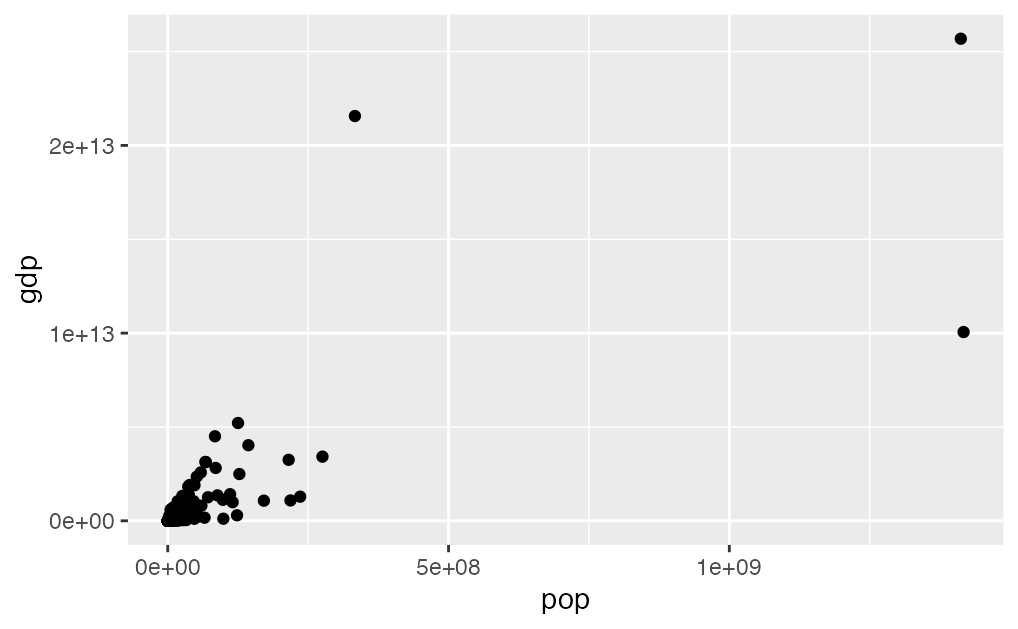

```r
df_gdppcap2 |> filter(year == 2022, region !="Aggregates") |>
  drop_na(gdp, pop) |>
  ggplot(aes(pop, gdp)) + geom_point()
```

Step 18. 左横に固まっていましたから、対数表示にしてみます。

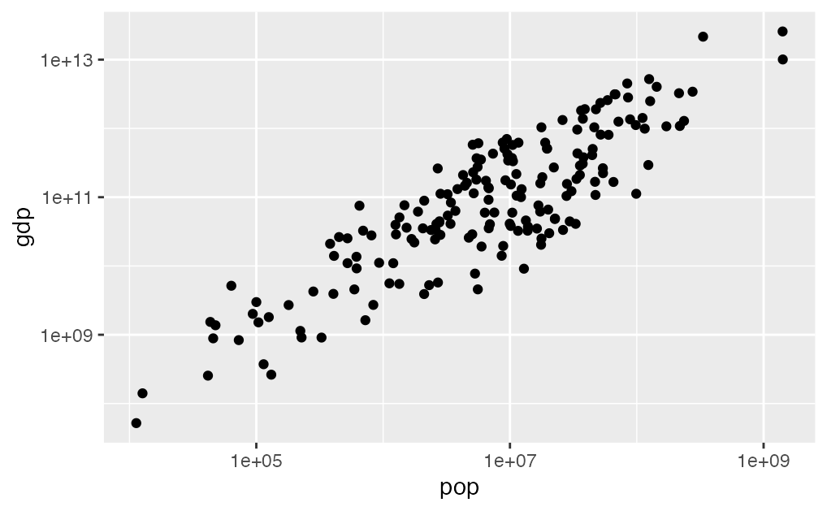

```r
df_gdppcap2 |> filter(year == 2022, region !="Aggregates") |>
  drop_na(gdp, pop) |>
  ggplot(aes(pop, gdp)) + geom_point() +
  scale_x_log10() + scale_y_log10()
```

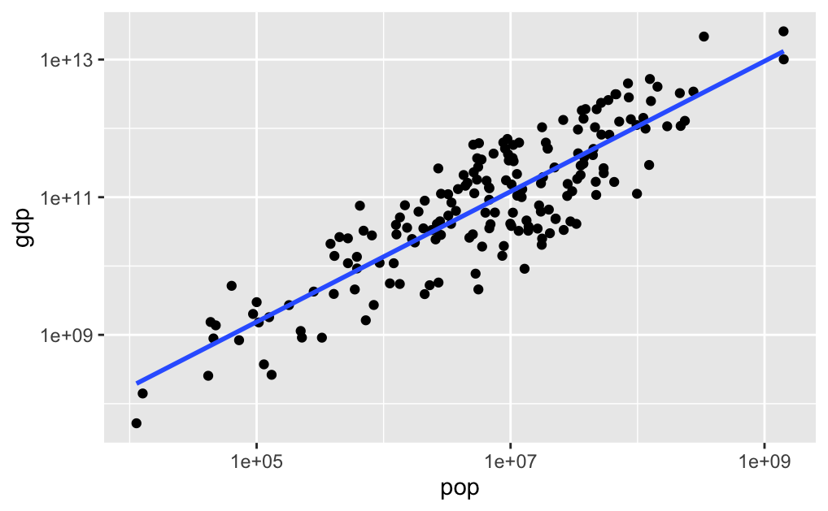

```r
df_gdppcap2 |> filter(year == 2022, region !="Aggregates") |>
  drop_na(gdp, pop) |>
  ggplot(aes(pop, gdp)) + geom_point() +
  geom_smooth(method = "lm", se = FALSE) +
  scale_x_log10() + scale_y_log10()
```

```r
df_gdppcap2 |> filter(year == 2022, region !="Aggregates") |>
  drop_na(gdp, pop) |> lm(log10(gdp) ~ log10(pop), data = _) |> summary()
```

```
Call:
lm(formula = log10(gdp) ~ log10(pop), data = drop_na(filter(df_gdppcap2,
    year == 2022, region != "Aggregates"), gdp, pop))

Residuals:
     Min       1Q   Median       3Q      Max
-1.22646 -0.39512  0.03996  0.42553  0.95842

Coefficients:
            Estimate Std. Error t value Pr(>|t|)
(Intercept)  4.45320    0.27485   16.20   <2e-16 ***
log10(pop)   0.94704    0.03998   23.69   <2e-16 ***
---
Signif. codes:  0 ‘***’ 0.001 ‘**’ 0.01 ‘*’ 0.05 ‘.’ 0.1 ‘ ’ 1

Residual standard error: 0.5117 on 181 degrees of freedom
Multiple R-squared:  0.7561,    Adjusted R-squared:  0.7548
F-statistic: 561.2 on 1 and 181 DF,  p-value: < 2.2e-16
```

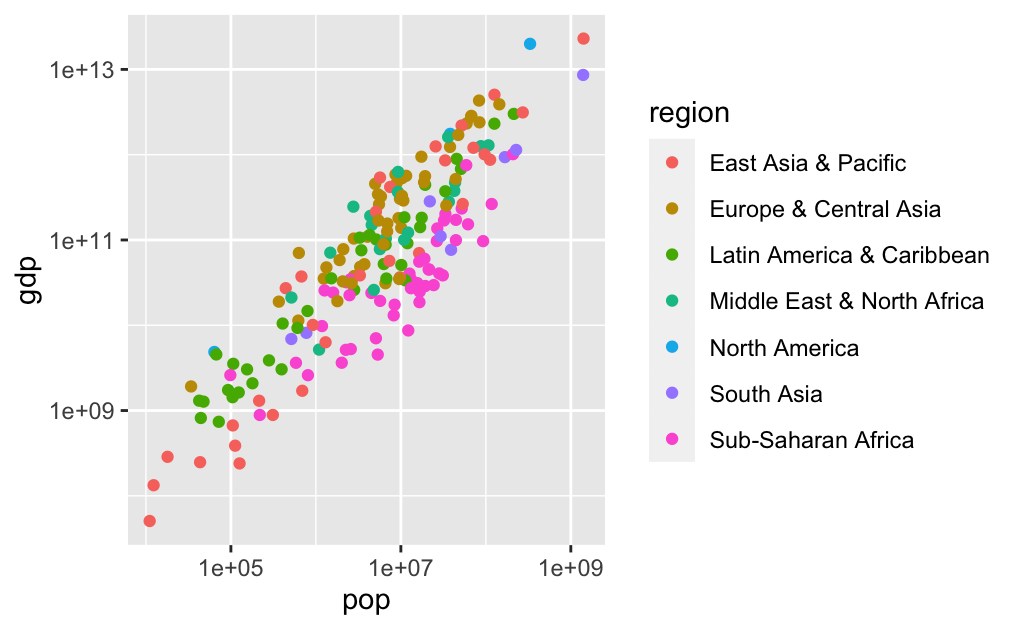

```r
df_gdppcap2 |> filter(year == 2020, region !="Aggregates") |> drop_na(gdp, pop) |>
  ggplot(aes(pop, gdp, color = region)) + geom_point() +
  scale_x_log10() + scale_y_log10()
```

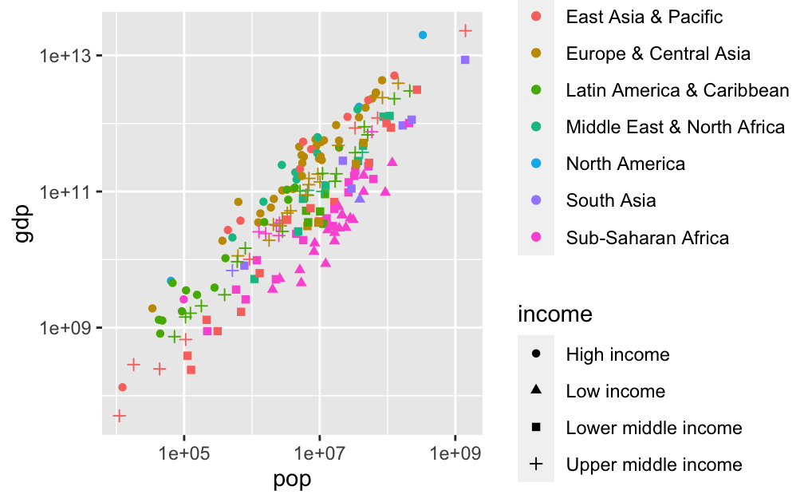

```r
df_gdppcap2 |> filter(year == 2020, region !="Aggregates") |>
  drop_na(gdp, pop) |>
  ggplot(aes(pop, gdp, color = region, shape = income)) + geom_point() +
  scale_x_log10() + scale_y_log10()
```

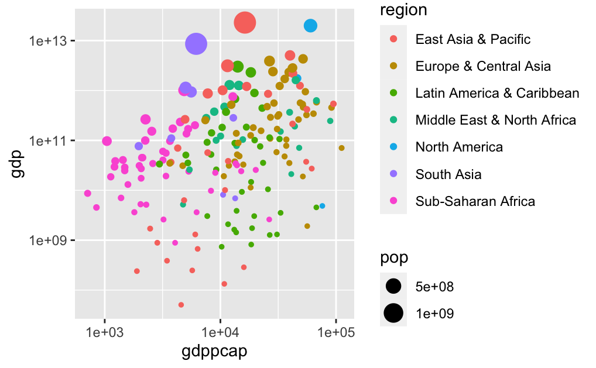

```r
df_gdppcap2 |> filter(year == 2020, region !="Aggregates") |>
  drop_na(gdp, gdppcap, pop) |>
  ggplot(aes(gdppcap, gdp, color = region, size = pop)) + geom_point() +
  scale_x_log10() + scale_y_log10()
```

```r
install.packages("plotly")
```

```r
library(plotly)
test <- df_gdppcap2 |> filter(year == 2020, region !="Aggregates") |> drop_na(gdp, pop) |>
  ggplot(aes(color = country, shape = region, pop, gdp)) + geom_point() +
  scale_x_log10() + scale_y_log10() + theme(legend.position = "none")
test |> ggplotly()
```

# 1 Exploratory Data Analysis (EDA)

[figure not shown]

*The image above is from [R4DS(2e)](https://r4ds.hadley.nz) by Hadley Wickham, Mine Çetinkaya-Rundel and Garrett Grolemund*

**EDA** is an iterative cycle that helps you understand what your data says. When you do EDA, you:

1. Generate questions about your data
2. Search for answers by visualising, transforming, and/or modeling your data
3. Use what you learn to refine your questions and/or generate new questions

EDA is an important part of any data analysis. You can use EDA to make discoveries about the world; or you can use EDA to ensure the quality of your data, asking questions about whether the data meets your standards or not. (Posit Primers: [EDA](https://posit.cloud/learn/primers/3.1))

## 1.1 GDP and GDP per Capita

1. GDP, PPP (constant 2017 international $): NY.GDP.MKTP.PP.KD
2. Population, total: SP.POP.TOTL
3. Calculate GDP per Capita
   - GDP per capita, PPP (constant 2017 international $): NY.GDP.PCAP.PP.KD
- GDP, PPP (constant 2017 international $) PPP GDP is gross domestic product converted to international dollars using purchasing power parity rates. An international dollar has the same purchasing power over GDP as the U.S. dollar has in the United States. GDP is the sum of gross value added by all resident producers in the country plus any product taxes and minus any subsidies not included in the value of the products. It is calculated without making deductions for depreciation of fabricated assets or for depletion and degradation of natural resources. Data are in constant 2017 international dollars. ID: NY.GDP.MKTP.PP.KD
- Population, total Total population is based on the de facto definition of population, which counts all residents regardless of legal status or citizenship. The values shown are midyear estimates. ID: SP.POP.TOTL

```r
df_gdppcap <- WDI(indicator = c(gdp = "NY.GDP.MKTP.PP.KD", pop = "SP.POP.TOTL", gdppcap = "NY.GDP.PCAP.PP.KD"), extra = TRUE)
```

```r
write_csv(df_gdppcap, "data/gdppcap.csv")
```

```r
df_gdppcap <- read_csv("data/gdppcap.csv")
```

```r
str(df_gdppcap)
```

```
spc_tbl_ [16,758 × 15] (S3: spec_tbl_df/tbl_df/tbl/data.frame)
 $ country    : chr [1:16758] "Afghanistan" "Afghanistan" "Afghanistan" "Afghanistan" ...
 $ iso2c      : chr [1:16758] "AF" "AF" "AF" "AF" ...
 $ iso3c      : chr [1:16758] "AFG" "AFG" "AFG" "AFG" ...
 $ year       : num [1:16758] 2014 2012 2009 2013 1971 ...
 $ status     : logi [1:16758] NA NA NA NA NA NA ...
 $ lastupdated: Date[1:16758], format: "2023-09-19" "2023-09-19" "2023-09-19" ...
 $ gdp        : num [1:16758] 7.02e+10 6.47e+10 4.99e+10 6.83e+10 NA ...
 $ pop        : num [1:16758] 32716210 30466479 27385307 31541209 11015857 ...
 $ gdppcap    : num [1:16758] 2144 2123 1824 2165 NA ...
 $ region     : chr [1:16758] "South Asia" "South Asia" "South Asia" "South Asia" ...
 $ capital    : chr [1:16758] "Kabul" "Kabul" "Kabul" "Kabul" ...
 $ longitude  : num [1:16758] 69.2 69.2 69.2 69.2 69.2 ...
 $ latitude   : num [1:16758] 34.5 34.5 34.5 34.5 34.5 ...
 $ income     : chr [1:16758] "Low income" "Low income" "Low income" "Low income" ...
 $ lending    : chr [1:16758] "IDA" "IDA" "IDA" "IDA" ...
 - attr(*, "spec")=
  .. cols(
  ..   country = col_character(),
  ..   iso2c = col_character(),
  ..   iso3c = col_character(),
  ..   year = col_double(),
  ..   status = col_logical(),
  ..   lastupdated = col_date(format = ""),
  ..   gdp = col_double(),
  ..   pop = col_double(),
  ..   gdppcap = col_double(),
  ..   region = col_character(),
  ..   capital = col_character(),
  ..   longitude = col_double(),
  ..   latitude = col_double(),
  ..   income = col_character(),
  ..   lending = col_character()
  .. )
 - attr(*, "problems")=<externalptr>
```

```r
df_gdppcap |> select(region, income, lending) |> lapply(unique)
```

```
$region
[1] "South Asia"                 "Aggregates"                 "Europe & Central Asia"
[4] "Middle East & North Africa" "East Asia & Pacific"        "Sub-Saharan Africa"
[7] "Latin America & Caribbean"  "North America"              NA

$income
[1] "Low income"          "Aggregates"          "Upper middle income" "Lower middle income"
[5] "High income"         NA                    "Not classified"

$lending
[1] "IDA"            "Aggregates"     "IBRD"           "Not classified" "Blend"
[6] NA
```

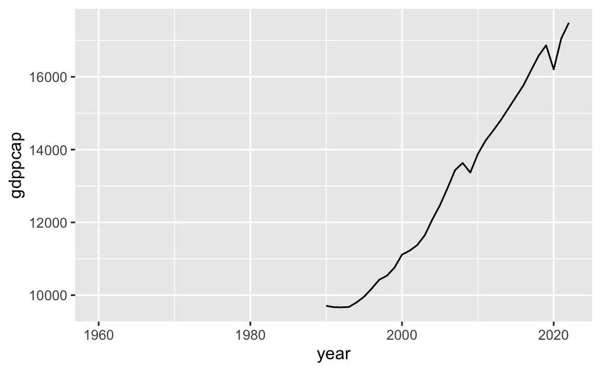

```r
COUNTRY <- "World"
df_gdppcap |> filter(country == COUNTRY) |>
  ggplot(aes(year, gdppcap)) + geom_line()
```

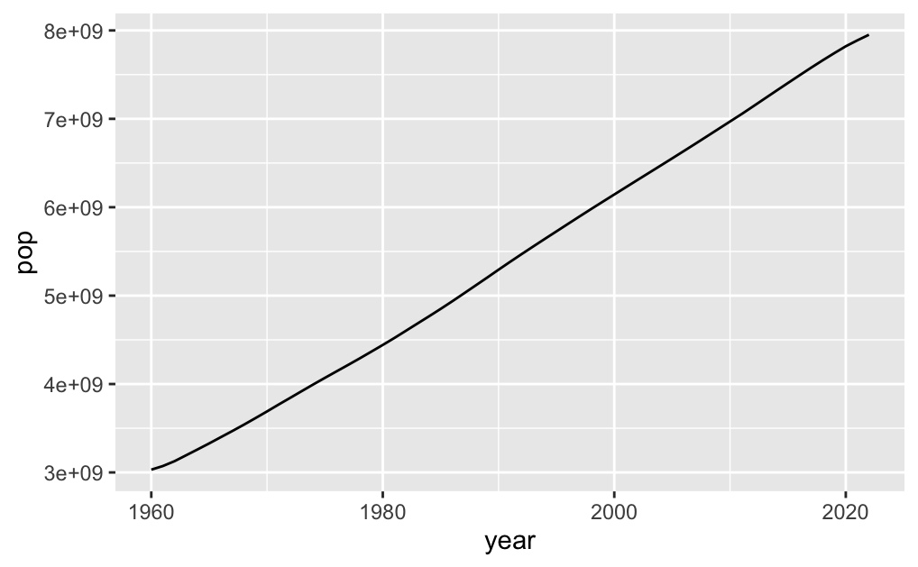

```r
COUNTRY <- "World"
df_gdppcap |> filter(country == COUNTRY) |>
  ggplot(aes(year, pop)) + geom_line()
```

#### 1.1.0.1 Exercise.

Write your observations and questions.

### 1.1.1 Visualization

Two useful questions.

1. What type of **variation** occurs **within** my variables?
2. What type of **covariation** occurs **between** my variables?

See [Link](https://posit.cloud/learn/primers/3.1).

#### 1.1.1.1 Ranks.

`arrange(desc(gdp))` is to reorder in descending order of `gdp,` `arrange(gdp)` in ascending order.

```r
df_gdppcap |> filter(year == 2022, region != "Aggregates") |>
  drop_na(gdp) |> arrange(desc(gdp))
```

| country | iso2c | iso3c | year | status | lastupdated | gdp | pop | gdppcap | region | capital | longitude | latitude | income | lending |
| --- | --- | --- | --- | --- | --- | --- | --- | --- | --- | --- | --- | --- | --- | --- |
| China | CN | CHN | 2022 | NA | 2023-09-19 | 2.568461e+13 | 1412175000 | 18187.9787 | East Asia & Pacific | Beijing | 116.286000 | 40.049500 | Upper middle income | IBRD |
| United States | US | USA | 2022 | NA | 2023-09-19 | 2.156470e+13 | 333287557 | 64702.9783 | North America | Washington D.C. | -77.032000 | 38.889500 | High income | Not classified |
| India | IN | IND | 2022 | NA | 2023-09-19 | 1.005674e+13 | 1417173173 | 7096.3389 | South Asia | New Delhi | 77.225000 | 28.635300 | Lower middle income | IBRD |
| Japan | JP | JPN | 2022 | NA | 2023-09-19 | 5.210350e+12 | 125124989 | 41641.1650 | East Asia & Pacific | Tokyo | 139.770000 | 35.670000 | High income | Not classified |
| Germany | DE | DEU | 2022 | NA | 2023-09-19 | 4.503322e+12 | 84079811 | 53560.0911 | Europe & Central Asia | Berlin | 13.411500 | 52.523500 | High income | Not classified |
| Russian Federation | RU | RUS | 2022 | NA | 2023-09-19 | 4.027358e+12 | 143555736 | 27584.1719 | Europe & Central Asia | Moscow | 37.617600 | 55.755800 | Upper middle income | IBRD |
| Indonesia | ID | IDN | 2022 | NA | 2023-09-19 | 3.418905e+12 | 275501339 | 12409.7589 | East Asia & Pacific | Jakarta | 106.830000 | -6.197520 | Lower middle income | IBRD |
| Brazil | BR | BRA | 2022 | NA | 2023-09-19 | 3.249827e+12 | 215313498 | 15093.4651 | Latin America & Caribbean | Brasilia | -47.929200 | -15.780100 | Upper middle income | IBRD |
| United Kingdom | GB | GBR | 2022 | NA | 2023-09-19 | 3.136344e+12 | 66971411 | 46831.0854 | Europe & Central Asia | London | -0.126236 | 51.500200 | High income | Not classified |
| France | FR | FRA | 2022 | NA | 2023-09-19 | 3.126376e+12 | 67935660 | 46019.6654 | Europe & Central Asia | Paris | 2.350970 | 48.856600 | High income | Not classified |

[output cut: 173 more lines]

#### 1.1.1.2 Exercises.

1. Find the top 10 of the countries with the highest GDP per capita.
2. Find the top 10 of the countries with the lowest GDP per capita.
3. Find the top 10 of the countries with the largest population.
4. Find the top 10 of the countries with the smallest population.

#### 1.1.1.3 Variation 1. Histogram

Histogram Video in Posit Primers: [Link](https://vimeo.com/221607341)

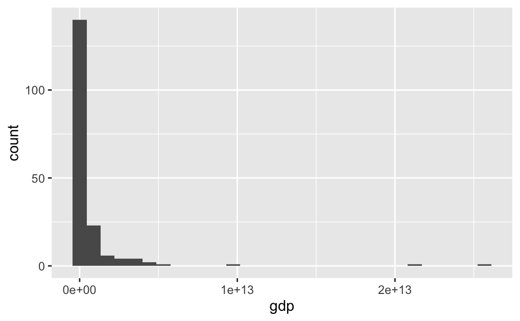

```r
df_gdppcap |> filter(year == 2022, region != "Aggregates") |> drop_na(gdp) |>
  ggplot(aes(gdp)) + geom_histogram()
```

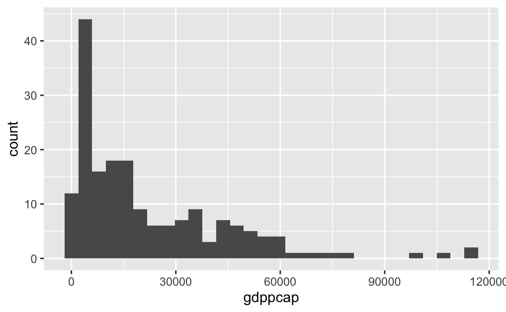

```r
df_gdppcap |> filter(year == 2022, region != "Aggregates") |> drop_na(gdppcap) |>
  ggplot(aes(gdppcap)) + geom_histogram()
```

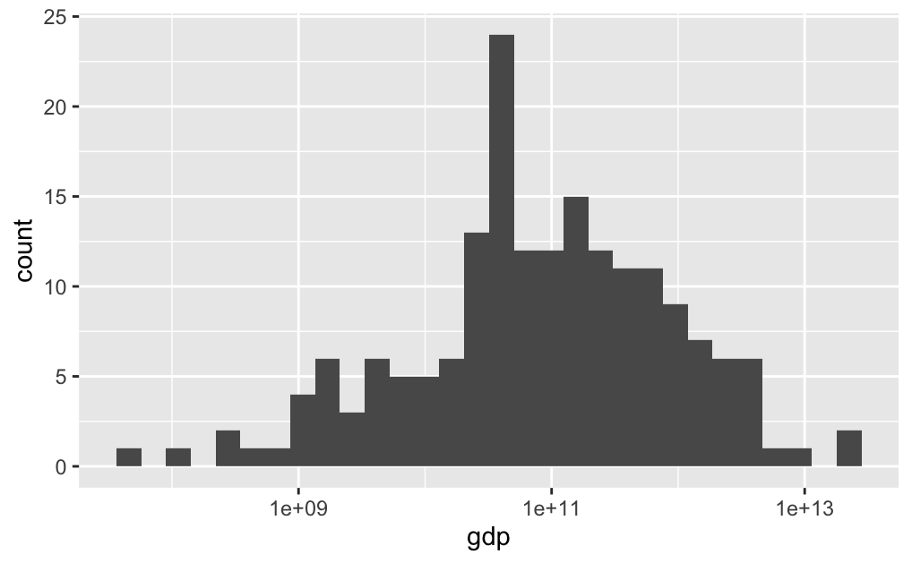

```r
df_gdppcap |> filter(year == 2022, region != "Aggregates") |> drop_na(gdp) |>
  ggplot(aes(gdp)) + geom_histogram() + scale_x_log10()
```

#### 1.1.1.4 Exercises.

1. Change bins, i.e., `geom_histogram(bins = 20)`, etc.

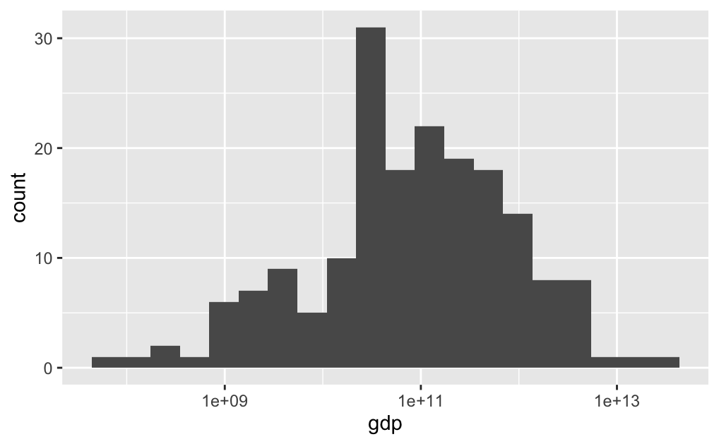

```r
df_gdppcap |> filter(year == 2022, region != "Aggregates") |> drop_na(gdp) |>
  ggplot(aes(gdp)) + geom_histogram(bins = 20) + scale_x_log10()
```

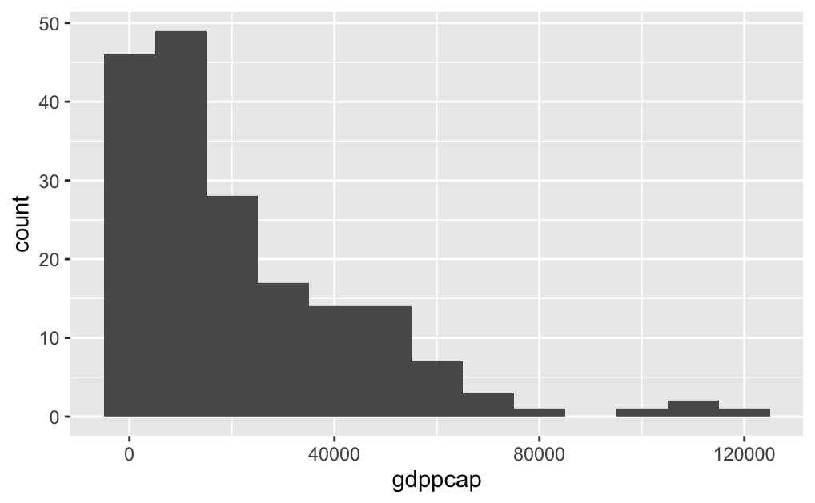

```r
df_gdppcap |> filter(year == 2022, region != "Aggregates") |> drop_na(gdppcap) |>
  ggplot(aes(gdppcap)) + geom_histogram(binwidth = 10000)
```

2. Create a similar histogram of gdppcap by using `scale_x_log10()` and adjust the number of bins.

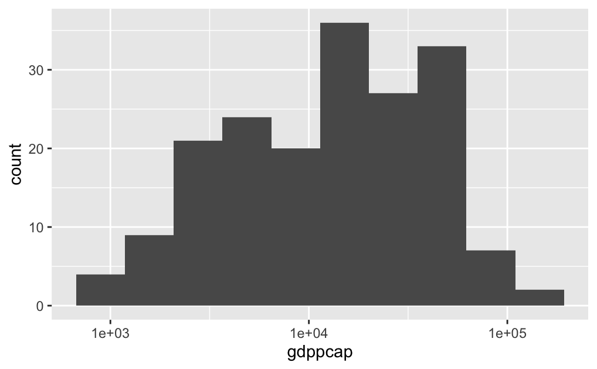

```r
df_gdppcap |> filter(year == 2022, region != "Aggregates") |> drop_na(gdppcap) |>
  ggplot(aes(gdppcap)) + geom_histogram(bins = 10) + scale_x_log10()
```

3. Create a similar histogram for population.

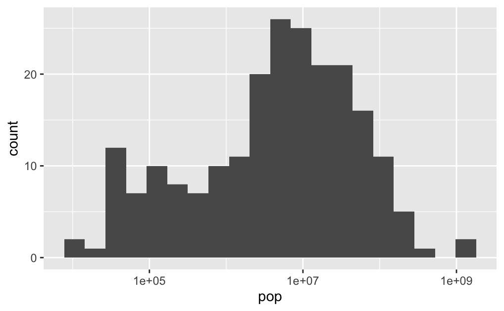

```r
df_gdppcap |> filter(year == 2022, region != "Aggregates") |> drop_na(pop) |>
  ggplot(aes(pop)) + geom_histogram(bins = 20) + scale_x_log10()
```

4. Write your observations and comments.

#### 1.1.1.5 Extra.

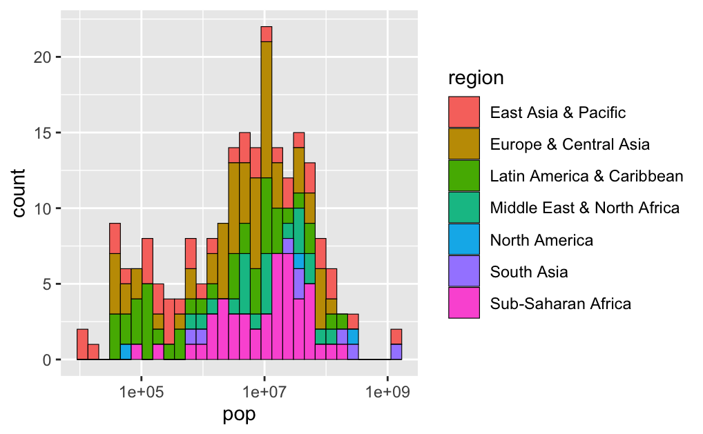

```r
df_gdppcap |> filter(year == 2022,region != "Aggregates") |> drop_na(pop) |>
  group_by(region) |>
  ggplot(aes(pop, fill = region)) + geom_histogram(col = "black", linewidth = 0.2) + scale_x_log10()
```

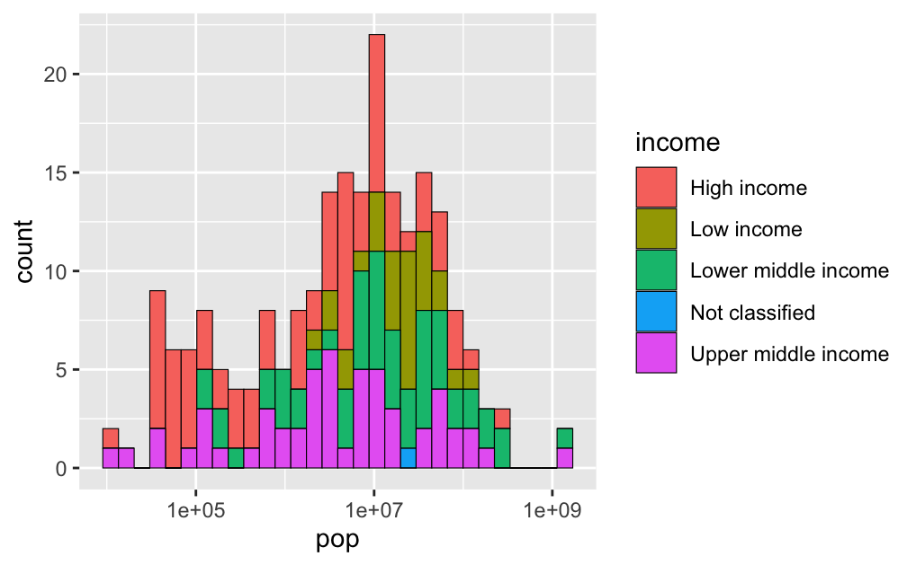

```r
df_gdppcap |> filter(year == 2022, region != "Aggregates") |> drop_na(pop) |>
  group_by(region) |>
  ggplot(aes(pop, fill = income)) + geom_histogram(col = "black", linewidth = 0.2) + scale_x_log10()
```

World by Income and Region: [[Link](https://datatopics.worldbank.org/world-development-indicators/the-world-by-income-and-region.html)]

#### 1.1.1.6 Variation 2. Boxplot

Boxplot Video in Posit Primers: [Link](https://vimeo.com/222358034)

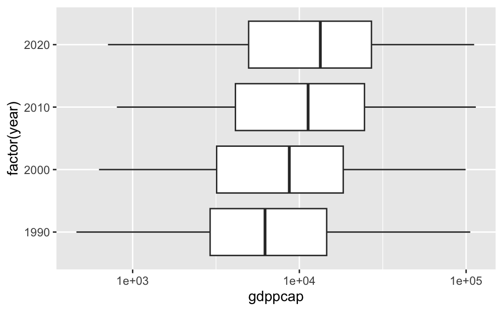

```r
df_gdppcap2 |> filter(year %in% c(1990,2000, 2010, 2020)) |> drop_na(gdppcap) |>
  ggplot(aes(gdppcap, factor(year))) + geom_boxplot() + scale_x_log10()
```

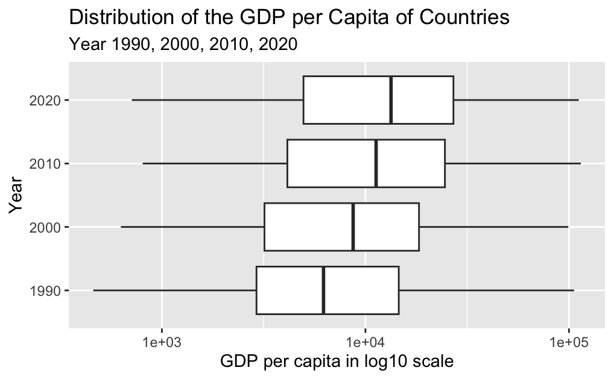

```r
df_gdppcap2 |> filter(year %in% c(1990,2000, 2010, 2020)) |> drop_na(gdppcap) |>
  ggplot(aes(gdppcap, factor(year))) + geom_boxplot() + scale_x_log10() +
  labs(title = "Distribution of the GDP per Capita of Countries", subtitle = "Year 1990, 2000, 2010, 2020",
       y = "Year", x = "GDP per capita in log10 scale")
```

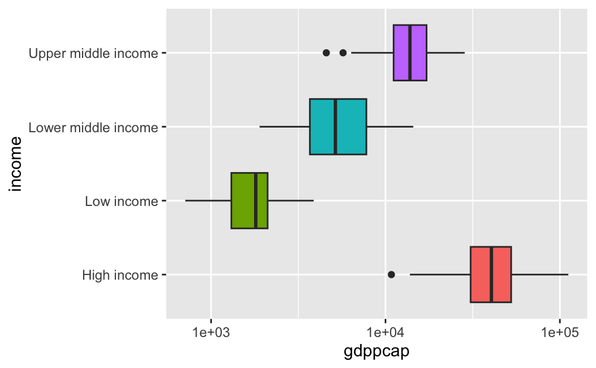

```r
df_gdppcap2 |> filter(year == 2020) |> drop_na(gdppcap) |>
  filter(income != "Aggregates") |>
  ggplot(aes(gdppcap, income, fill = income)) + geom_boxplot() + scale_x_log10() +
  theme(legend.position = "none")
```

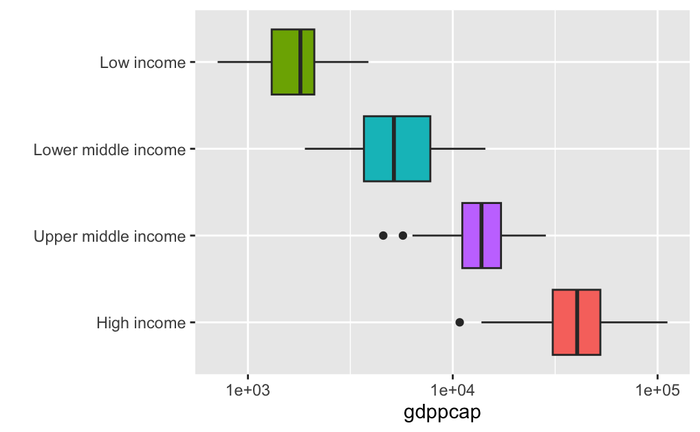

```r
df_gdppcap2 |> filter(year == 2020) |> drop_na(gdppcap) |>
  filter(income != "Aggregates") |>
  ggplot(aes(gdppcap, factor(income, levels = c("High income", "Upper middle income", "Lower middle income", "Low income")), fill = income)) + geom_boxplot() + scale_x_log10() +
  labs(y = "") +
  theme(legend.position = "none")
```

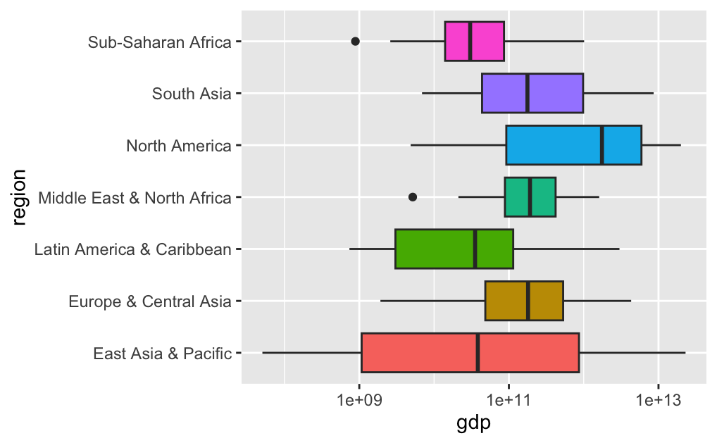

```r
df_gdppcap2 |> filter(year == 2020) |> drop_na(gdp) |>
  filter(income != "Aggregates") |>
  ggplot(aes(gdp, region, fill = region)) + geom_boxplot() + scale_x_log10() +
  theme(legend.position = "none")
```